# Ejercicios_Diagnosis_del_modelo

David Caceres

17/4/2022

## Faraway. Capítulo 6.

### Problema 6.1. pág. 97

Using the sat dataset, fit a model with the total SAT score as the response and expend, salary, ratio and takers as predictors. Perform regression diagnostics on this model to answer the following questions. Display any plots that are relevant. Do not provide any plots about which you have nothing to say. Suggest possible improvements or corrections to the model where appropriate.

```r
require(faraway)
data("sat")
head(sat)
```

```
##            expend ratio salary takers verbal math total
## Alabama     4.405  17.2 31.144      8    491  538  1029
## Alaska      8.963  17.6 47.951     47    445  489   934
## Arizona     4.778  19.3 32.175     27    448  496   944
## Arkansas    4.459  17.1 28.934      6    482  523  1005
## California  4.992  24.0 41.078     45    417  485   902
## Colorado    5.443  18.4 34.571     29    462  518   980
```

```r
lmod<-lm(total ~ expend + ratio + salary + takers, data =sat)
summary(lmod)
```

```
##
## Call:
## lm(formula = total ~ expend + ratio + salary + takers, data = sat)
##
## Residuals:
##     Min      1Q  Median      3Q     Max
## -90.531 -20.855  -1.746  15.979  66.571
##
## Coefficients:
##              Estimate Std. Error t value Pr(>|t|)
## (Intercept) 1045.9715    52.8698  19.784  < 2e-16 ***
## expend         4.4626    10.5465   0.423    0.674
## ratio         -3.6242     3.2154  -1.127    0.266
## salary         1.6379     2.3872   0.686    0.496
## takers        -2.9045     0.2313 -12.559 2.61e-16 ***
## ---
## Signif. codes:  0 '***' 0.001 '**' 0.01 '*' 0.05 '.' 0.1 ' ' 1
##
## Residual standard error: 32.7 on 45 degrees of freedom
## Multiple R-squared:  0.8246, Adjusted R-squared:  0.809
## F-statistic: 52.88 on 4 and 45 DF,  p-value: < 2.2e-16
```

#### Check the constant variance assumption for the errors.

Represento los valores ajustados frente a los residuos para ver la desviación respecto de cero. A simple vista, parece que los puntos están equitativamente distribuidos sobre y bajo la línea central, lo cual indicaría una varianza constante.

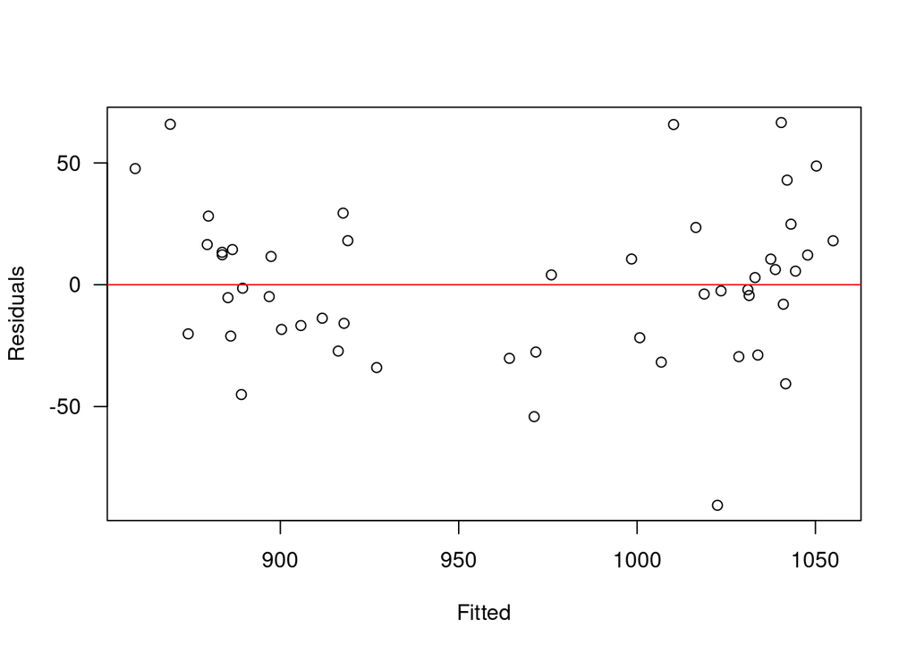

```r
par(las=1)
plot(fitted(lmod), residuals(lmod), xlab="Fitted", ylab="Residuals")
abline(h=0, col="red")
```

Los valores ajustados respecto a los residuos en valor absoluto, también parecen tener una relacion aleatoria.

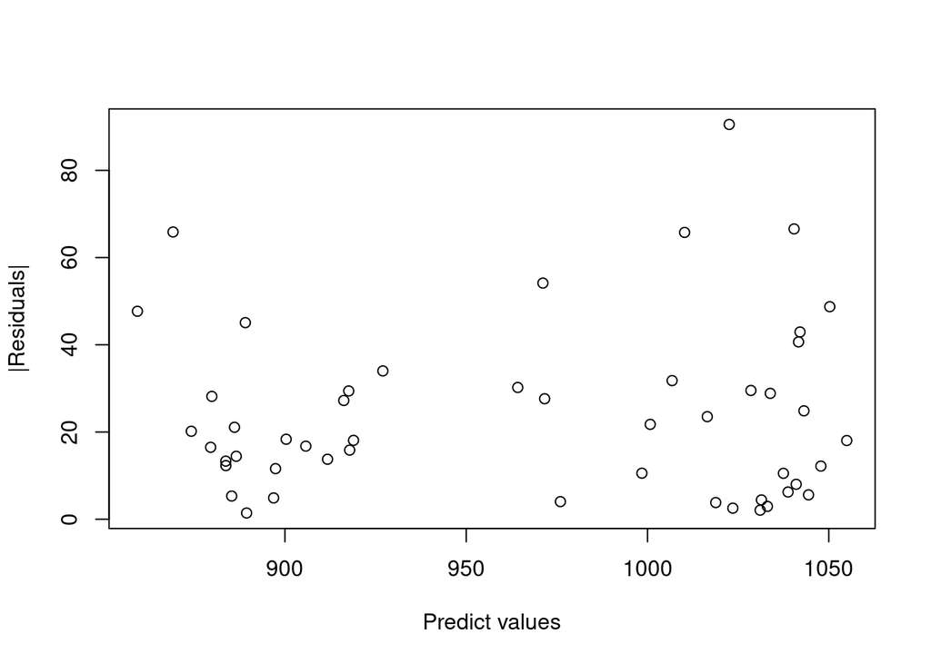

```r
plot(fitted(lmod),abs(residuals(lmod)),xlab="Predict values",ylab="|Residuals|")
```

Para comprobarlo, veamos el p-valor que nos dará una idea de la pendiente de la recta que representa a estos valores.

```r
summary(lm(abs(residuals(lmod)) ~ fitted(lmod)))
```

```
##
## Call:
## lm(formula = abs(residuals(lmod)) ~ fitted(lmod))
##
## Residuals:
##     Min      1Q  Median      3Q     Max
## -22.827 -14.323  -5.001   6.204  65.754
##
## Coefficients:
##              Estimate Std. Error t value Pr(>|t|)
## (Intercept)  10.60384   40.82315   0.260    0.796
## fitted(lmod)  0.01386    0.04216   0.329    0.744
##
## Residual standard error: 20.05 on 48 degrees of freedom
## Multiple R-squared:  0.002247,   Adjusted R-squared:  -0.01854
## F-statistic: 0.1081 on 1 and 48 DF,  p-value: 0.7438
```

#### Check the normality assumption.

EL gráfico de Q-Q plot suele ser el elegido para este test

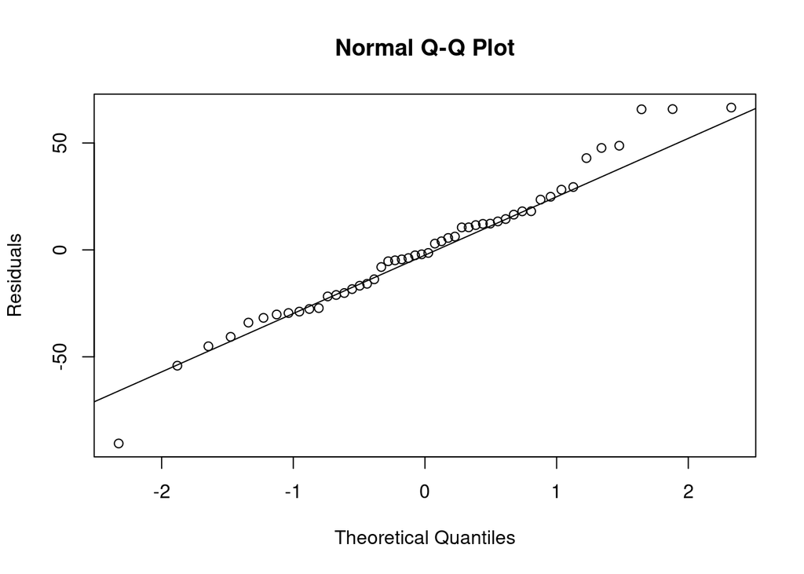

```r
par(mfrow=c(1,1))
qqnorm(residuals(lmod), ylab="Residuals")
qqline(residuals(lmod))
```

```r
shapiro.test(residuals(lmod))
```

```
##
##  Shapiro-Wilk normality test
##
## data:  residuals(lmod)
## W = 0.97691, p-value = 0.4304
```

#### Check for large leverage points.

```r
hatv <- hatvalues(lmod)
head(sort(hatv,decreasing=T))
```

```
##        Utah  California Connecticut  New Jersey    New York      Alaska
##   0.2921128   0.2821179   0.2254519   0.2220978   0.1915752   0.1803061
```

```r
# Vemos los datos con mayor Leverage
```

```r
# BUscamos que observaciones tienen un leverage que supone el doble del valor medio.
p <- length(lmod$coefficients) # k+1
n <- length(lmod$fitted.values)
leverage.mean <- p/n # (k+1)/n
which(hatv > 2*leverage.mean)
```

```
##  California Connecticut  New Jersey        Utah
##           5           7          30          44
```

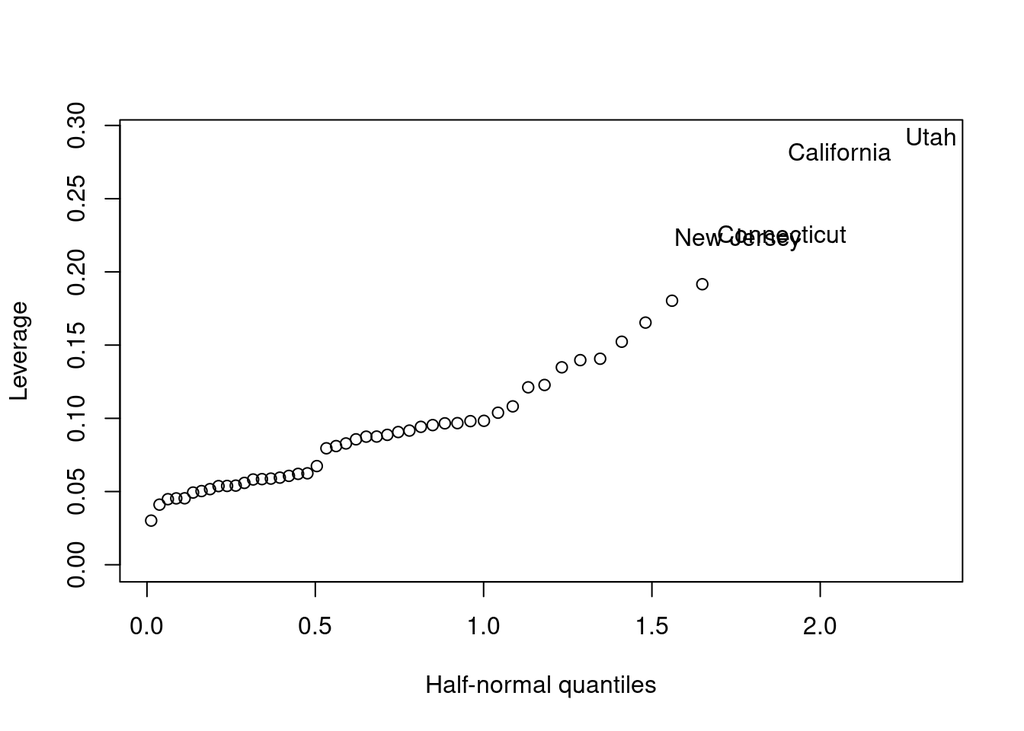

```r
# Graficamente

estados <- row.names(sat)
halfnorm(hatv,labs=estados,nlab = 4,ylab="Leverage")
```

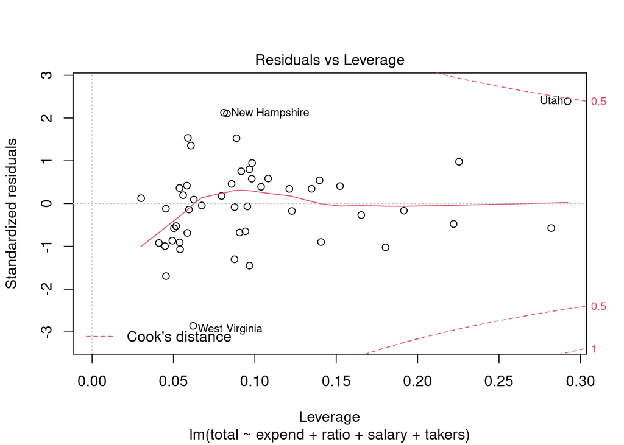

```r
# Laverage frente a residuos estandarizados

plot(lmod, which=5)
```

Vemos que Utah, California, Connecticut y New jersey tienen un laverage superior al cut off.

#### Check for outliers.

```r
# Studentizamos los residuos y buscamos los más grandes

stud <- rstudent(lmod)
head(sort(abs(stud),decreasing=TRUE))
```

```
## West Virginia          Utah  North Dakota New Hampshire        Nevada
##      3.124428      2.529587      2.213686      2.190006      1.732004
##          Iowa
##      1.560374
```

```r
# Será un outlier, todo residuo cuyo valor studentizado en valor absoluto, sea mayor que 2
which(abs(stud)>2)
```

```
## New Hampshire  North Dakota          Utah West Virginia
##            29            34            44            48
```

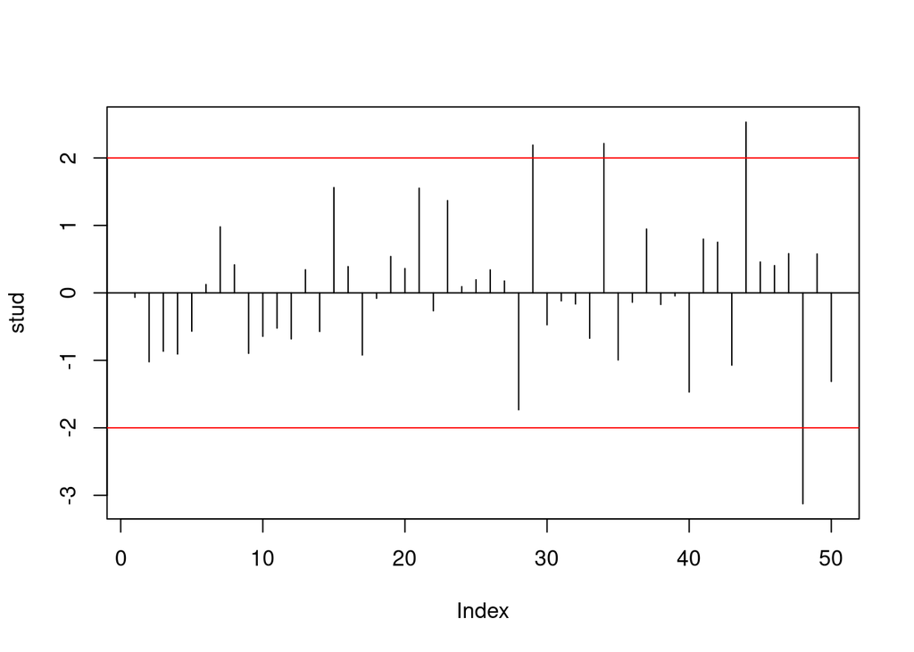

```r
# Los 4 primeros parecen outliers

# Lo confirmamos graficamente

plot(stud, type="h")
abline(h=-2, col="red"); abline(h=0); abline(h=2, col="red")
```

Realizamos un bonferroni para definir finalmente si están por encima del valor cŕitico de la t de student

```r
grlib <- n-p-1
which(abs(stud) > abs(qt(0.05/(2*n),grlib)))
```

```
## named integer(0)
```

Con el test de Bonferroni, vemos que no hay ningún outlier, pero podemos estar ante velores atípicos o influyentes.

#### Check for influential points.

```r
# Calculamos las distancias de cook

cook <- cooks.distance(lmod)
head(cook)
```

```
##      Alabama       Alaska      Arizona     Arkansas   California     Colorado
## 9.320823e-05 4.581008e-02 7.787666e-03 9.366213e-03 2.571304e-02 9.733862e-05
```

## Problema 6.2. pág. 97

Using the teengamb dataset, fit a model with gamble as the response and the other variables as predictors. Answer the questions posed in the previous question.

```r
data(teengamb,package="faraway")
head(teengamb)
```

```
##   sex status income verbal gamble
## 1   1     51   2.00      8    0.0
## 2   1     28   2.50      8    0.0
## 3   1     37   2.00      6    0.0
## 4   1     28   7.00      4    7.3
## 5   1     65   2.00      8   19.6
## 6   1     61   3.47      6    0.1
```

```r
lmod1 <- lm(gamble~.,data=teengamb)
summary(lmod1)
```

```
##
## Call:
## lm(formula = gamble ~ ., data = teengamb)
##
## Residuals:
##     Min      1Q  Median      3Q     Max
## -51.082 -11.320  -1.451   9.452  94.252
##
## Coefficients:
##              Estimate Std. Error t value Pr(>|t|)
## (Intercept)  22.55565   17.19680   1.312   0.1968
## sex         -22.11833    8.21111  -2.694   0.0101 *
## status        0.05223    0.28111   0.186   0.8535
## income        4.96198    1.02539   4.839 1.79e-05 ***
## verbal       -2.95949    2.17215  -1.362   0.1803
## ---
## Signif. codes:  0 '***' 0.001 '**' 0.01 '*' 0.05 '.' 0.1 ' ' 1
##
## Residual standard error: 22.69 on 42 degrees of freedom
## Multiple R-squared:  0.5267, Adjusted R-squared:  0.4816
## F-statistic: 11.69 on 4 and 42 DF,  p-value: 1.815e-06
```

#### a) Varianza constante

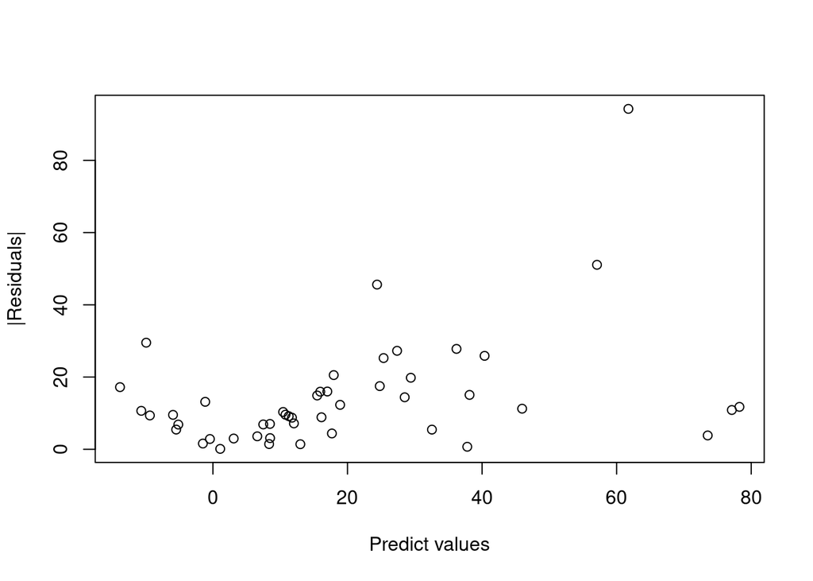

```r
plot(fitted(lmod1),abs(residuals(lmod1)),xlab="Predict values",ylab="|Residuals|")
```

```r
sumary(lm(sqrt(abs(residuals(lmod1)))~fitted(lmod1)))
```

```
##               Estimate Std. Error t value Pr(>|t|)
## (Intercept)   2.878378   0.312183  9.2201 6.21e-12
## fitted(lmod1) 0.026790   0.010496  2.5523  0.01417
##
## n = 47, p = 2, Residual SE = 1.62834, R-Squared = 0.13
```

#### b) Normalidad

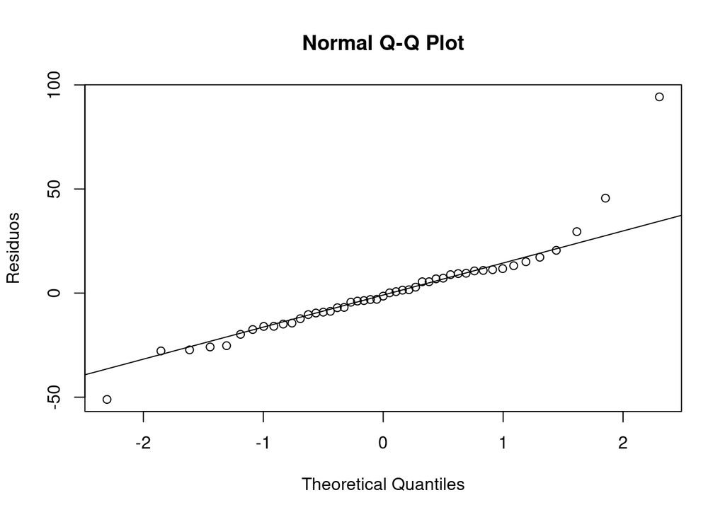

```r
qqnorm(residuals(lmod1),ylab="Residuos")
qqline(residuals(lmod1))
```

Vemos una cola larga superior, y otra algo más corta en la inferior

```r
shapiro.test(residuals(lmod1))
```

```
##
##  Shapiro-Wilk normality test
##
## data:  residuals(lmod1)
## W = 0.86839, p-value = 8.16e-05
```

El test de shapiro nos dice que tenemos que rechazar la normalidad.

#### c) Leverage

```r
hatv <- hatvalues(lmod1)
head(sort(hatv,decreasing=T))
```

```
##        35        42        31        33         6        17
## 0.3118029 0.3016088 0.2395031 0.2213439 0.1637856 0.1400034
```

```r
p <- length(lmod1$coefficients) # k+1
n <- length(lmod1$fitted.values)
leverage.mean <- p/n # (k+1)/n
which(hatv > 2*leverage.mean)
```

```
## 31 33 35 42
## 31 33 35 42
```

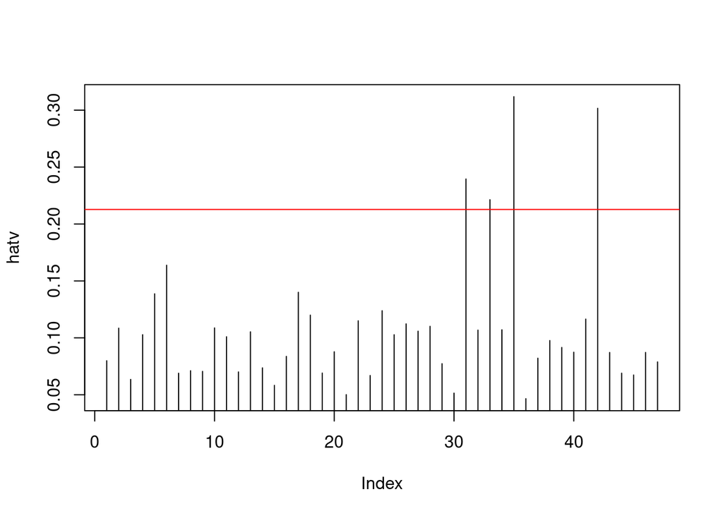

```r
plot(hatv, type="h")
abline(h=2*leverage.mean, col="red")
```

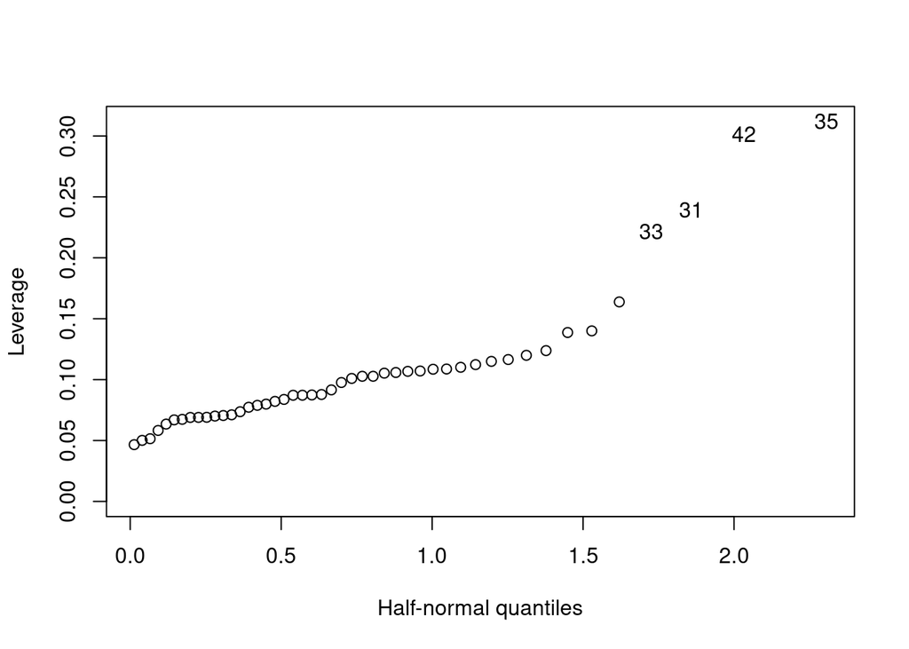

```r
halfnorm(hatv,nlab=4,ylab="Leverage")
```

Hay 4 valores que claramente superan el laverage medio